# 1 Setup and reproducibility

# 23a Train A2C on calibrated Env V2 and compare vs heuristics and DQN/DDQN

Here A2C is retrained from scratch in the calibrated environment. The same actor–critic architecture and hyperparameters are reused, but rewards reflect the empirically calibrated V2 cost. After training, the greedy policy is evaluated and appended to the calibrated comparison table alongside DQN, Double DQN, and the heuristics. The section examines whether A2C converges toward the same conservative behavior as the value-based agents and whether any risk or throughput differences emerge in the tail metrics. It helps clarify the role of policy-gradient methods once the environment is tuned to real-world data.

```
[A2C-V2] steps=  2016 episodes=  63 last_ep_return=   0.00 loss=171569.984
[A2C-V2] steps=  4000 episodes= 125 last_ep_return=   0.00 loss=5306.212
[A2C-V2] steps=  6016 episodes= 188 last_ep_return=   0.00 loss=4296.464
[A2C-V2] steps=  8000 episodes= 250 last_ep_return=   0.00 loss=5132.193
[A2C-V2] steps= 10016 episodes= 313 last_ep_return=   0.00 loss=4339.180
[A2C-V2] steps= 12000 episodes= 375 last_ep_return=   0.00 loss=1564.181
[A2C-V2] steps= 14016 episodes= 438 last_ep_return=   0.00 loss=5473.713
[A2C-V2] steps= 16000 episodes= 500 last_ep_return=   0.00 loss=643.545
[A2C-V2] steps= 18016 episodes= 563 last_ep_return=   0.00 loss=2245.472
[A2C-V2] steps= 20000 episodes= 625 last_ep_return=   0.00 loss=5524.346
[A2C-V2] steps= 22016 episodes= 688 last_ep_return=   0.00 loss=926.045
[A2C-V2] steps= 24000 episodes= 750 last_ep_return=   0.00 loss=16761.656
[A2C-V2] steps= 26016 episodes= 813 last_ep_return=   0.00 loss=520.139
[A2C-V2] steps= 28000 episodes= 875 last_ep_return=   0.00 loss=19708.666
[A2C-V2] steps= 30016 episodes= 938 last_ep_return=   0.00 loss=1977.669
[A2C-V2] steps= 32000 episodes=1000 last_ep_return=   0.00 loss=4566.626
[A2C-V2] steps= 34016 episodes=1063 last_ep_return=   0.00 loss=7944.655
[A2C-V2] steps= 36000 episodes=1125 last_ep_return=   0.00 loss=22877.480
[A2C-V2] steps= 38016 episodes=1188 last_ep_return=   0.00 loss=4412.614
[A2C-V2] steps= 40000 episodes=1250 last_ep_return=   0.00 loss=19958.215
Saved: report_artifacts/a2c_rewards_envv2_calibrated_20251125_022217.png
Heuristics vs DQN/DDQN vs A2C (calibrated Env V2)
                policy  mean_cost_v2  mean_cost_v2_ci_lo  mean_cost_v2_ci_hi  \
0              a2c_cal    885.837097          831.233643          942.396912
2             ddqn_cal    885.837097          831.233643          942.396912
3              dqn_cal    885.837097          831.233643          942.396912
5          no_overbook    885.837097          831.233643          942.396912
4        mild_overbook   2212.370605         2107.746826         2314.161133
1  aggressive_overbook   2279.402588         2179.580322         2379.508301
6               random   2317.976074         2211.845703         2418.713867

       var5_v2     cvar5_v2     served  mean_revenue  mean_shortfall_penalty
0  1678.574951  1957.992188  51.203125           0.0                     0.0
2  1678.574951  1957.992188  51.203125           0.0                     0.0
3  1678.574951  1957.992188  51.203125           0.0                     0.0
5  1678.574951  1957.992188  51.203125           0.0                     0.0
4  3483.850098  3830.184814  57.347656           0.0                     0.0
1  3650.375000  4107.484375  57.511719           0.0                     0.0
6  3672.975098  4079.653809  57.527344           0.0                     0.0
Saved: report_artifacts/ecdf_envv2_calibrated_a2c_20251125_022225.png
```

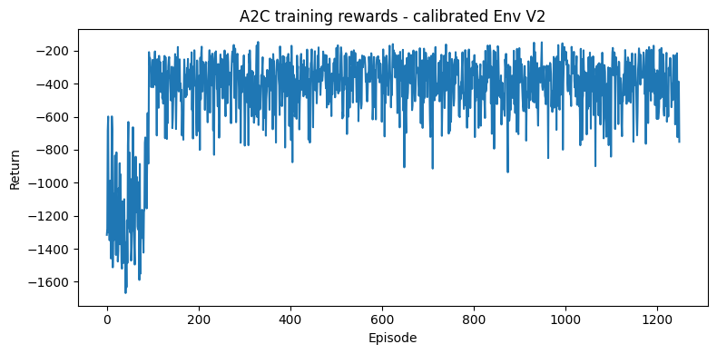

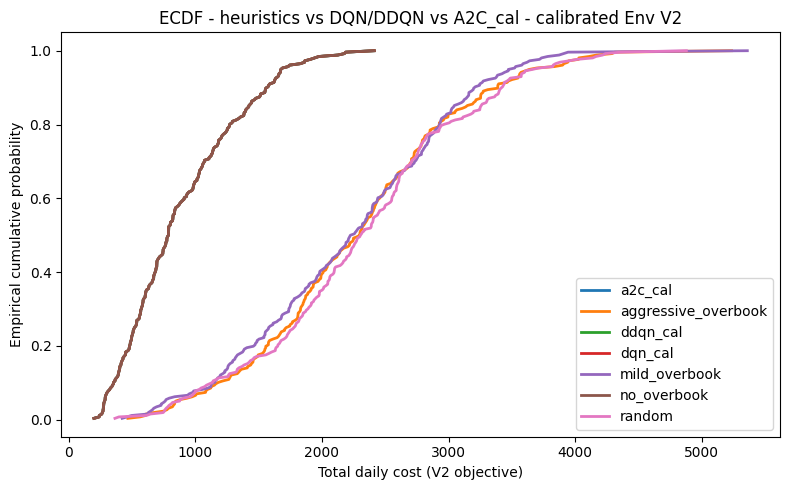

```python
a2c_cal_v2, logs_a2c_cal_v2 = train_a2c_v2(cfg_calibrated)

# Plot training rewards
plt.figure(figsize=(8, 4))
plt.plot(logs_a2c_cal_v2["rewards"])
plt.xlabel("Episode")
plt.ylabel("Return")
plt.title("A2C training rewards - calibrated Env V2")
plt.tight_layout()
path_a2c_cal_plot = os.path.join(
    ART_DIR, f"a2c_rewards_envv2_calibrated_{now_tag()}.png"
)
plt.savefig(path_a2c_cal_plot, dpi=130)
print("Saved:", path_a2c_cal_plot)


# greedy evaluation for an actor-critic policy
def evaluate_greedy_v2_a2c(ac_model, env_cfg, episodes=256):
    env = ClinicEnvV2(env_cfg)

    def greedy(obs, env_):
        with torch.no_grad():
            x = torch.tensor(obs, dtype=torch.float32, device=device).unsqueeze(0)
            # ac_model returns (policy_logits, value)
            logits, _ = ac_model(x)
            action = int(logits.argmax(dim=-1).item())
        return action

    return pd.DataFrame([run_episode_v2(env, greedy) for _ in range(episodes)])


# Evaluate A2C on calibrated env
df_a2c_cal_v2 = evaluate_greedy_v2_a2c(
    a2c_cal_v2, cfg_calibrated, episodes=256
).assign(policy="a2c_cal")

# Heuristic baselines under calibrated config
df_heur_cal = eval_policies_v2(cfg_calibrated, POLICIES, episodes=256)

frames = [df_heur_cal, df_a2c_cal_v2]

# Add calibrated DQN and Double DQN
if "qnet_dqn_cal_v2" in globals():
    df_dqn_cal = evaluate_greedy_v2(
        qnet_dqn_cal_v2, cfg_calibrated, episodes=256
    ).assign(policy="dqn_cal")
    frames.append(df_dqn_cal)

if "qnet_ddqn_cal_v2" in globals():
    df_ddqn_cal = evaluate_greedy_v2(
        qnet_ddqn_cal_v2, cfg_calibrated, episodes=256
    ).assign(policy="ddqn_cal")
    frames.append(df_ddqn_cal)

df_cmp_a2c_cal = pd.concat(frames, ignore_index=True)

summary_a2c_cal = summarize_v2(df_cmp_a2c_cal, alpha=0.05)
summary_a2c_cal = summary_a2c_cal.sort_values("mean_cost_v2")
print("Heuristics vs DQN/DDQN vs A2C (calibrated Env V2)")
print(summary_a2c_cal)

# ECDF plot
plt.figure(figsize=(8, 5))
focus_policies = [
    "no_overbook",
    "mild_overbook",
    "aggressive_overbook",
    "random",
    "dqn_cal",
    "ddqn_cal",
    "a2c_cal",
]
for name, g in df_cmp_a2c_cal.groupby("policy"):
    if name not in focus_policies:
        continue
    y, x = ecdf(g["cost_total_v2"].to_numpy())
    plt.plot(y, x, label=name, linewidth=2.0)

plt.xlabel("Total daily cost (V2 objective)")
plt.ylabel("Empirical cumulative probability")
plt.title("ECDF - heuristics vs DQN/DDQN vs A2C_cal - calibrated Env V2")
plt.legend()
plt.tight_layout()
path_ecdf_a2c_cal = os.path.join(
    ART_DIR, f"ecdf_envv2_calibrated_a2c_{now_tag()}.png"
)
plt.savefig(path_ecdf_a2c_cal, dpi=130)
print("Saved:", path_ecdf_a2c_cal)
```

# 23b Train PPO on calibrated Env V2 and extend the comparison

This section repeats the calibration-aware training for PPO. Using the same calibrated configuration, PPO is trained with the clipped objective and logged as before. The resulting policy is evaluated and included in the growing calibrated summary, so that all major actor–critic variants can be compared consistently. The section focuses on whether PPO provides any additional robustness or improved tail performance relative to A2C, DQN, and Double DQN. Together with 23a, it completes the picture of how policy-gradient agents behave under realistic clinic conditions.

```
[PPO-V2] steps=  4096 episodes= 128 last_ep_return=   0.00 loss=84520.406
[PPO-V2] steps=  8192 episodes= 256 last_ep_return=   0.00 loss=8870.389
[PPO-V2] steps= 12032 episodes= 376 last_ep_return=   0.00 loss=8236.260
[PPO-V2] steps= 16128 episodes= 504 last_ep_return=   0.00 loss=10174.438
[PPO-V2] steps= 20224 episodes= 632 last_ep_return=   0.00 loss=5993.416
[PPO-V2] steps= 24064 episodes= 752 last_ep_return=   0.00 loss=7141.345
[PPO-V2] steps= 28160 episodes= 880 last_ep_return=   0.00 loss=4000.291
[PPO-V2] steps= 32000 episodes=1000 last_ep_return=   0.00 loss=2477.488
[PPO-V2] steps= 36096 episodes=1128 last_ep_return=   0.00 loss=2615.457
[PPO-V2] steps= 40192 episodes=1256 last_ep_return=   0.00 loss=2569.206
[PPO-V2] steps= 44032 episodes=1376 last_ep_return=   0.00 loss=3228.329
[PPO-V2] steps= 48128 episodes=1504 last_ep_return=   0.00 loss=3992.687
[PPO-V2] steps= 52224 episodes=1632 last_ep_return=   0.00 loss=2928.204
[PPO-V2] steps= 56064 episodes=1752 last_ep_return=   0.00 loss=2879.034
[PPO-V2] steps= 60160 episodes=1880 last_ep_return=   0.00 loss=3630.308
[PPO-V2] steps= 64000 episodes=2000 last_ep_return=   0.00 loss=3747.671
[PPO-V2] steps= 68096 episodes=2128 last_ep_return=   0.00 loss=2399.160
[PPO-V2] steps= 72192 episodes=2256 last_ep_return=   0.00 loss=3410.473
[PPO-V2] steps= 76032 episodes=2376 last_ep_return=   0.00 loss=4224.824
[PPO-V2] steps= 80000 episodes=2500 last_ep_return=   0.00 loss=4493.722
Saved: report_artifacts/ppo_rewards_envv2_calibrated_20251125_022807.png
Heuristics vs DQN/DDQN vs A2C_cal vs PPO_cal (calibrated Env V2)
                policy  mean_cost_v2  mean_cost_v2_ci_lo  mean_cost_v2_ci_hi  \
0              a2c_cal    885.837097          831.233643          942.396912
2             ddqn_cal    885.837097          831.233643          942.396912
3              dqn_cal    885.837097          831.233643          942.396912
5          no_overbook    885.837097          831.233643          942.396912
6              ppo_cal    885.837097          831.233643          942.396912
4        mild_overbook   2212.370605         2107.746826         2314.161133
1  aggressive_overbook   2279.402588         2179.580322         2379.508301
7               random   2317.976074         2211.845703         2418.713867

       var5_v2     cvar5_v2     served  mean_revenue  mean_shortfall_penalty
0  1678.574951  1957.992188  51.203125           0.0                     0.0
2  1678.574951  1957.992188  51.203125           0.0                     0.0
3  1678.574951  1957.992188  51.203125           0.0                     0.0
5  1678.574951  1957.992188  51.203125           0.0                     0.0
6  1678.574951  1957.992188  51.203125           0.0                     0.0
4  3483.850098  3830.184814  57.347656           0.0                     0.0
1  3650.375000  4107.484375  57.511719           0.0                     0.0
7  3672.975098  4079.653809  57.527344           0.0                     0.0
Saved: report_artifacts/ecdf_envv2_calibrated_ppo_20251125_022813.png
```

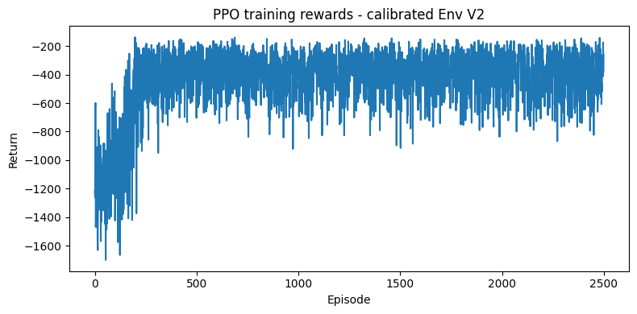

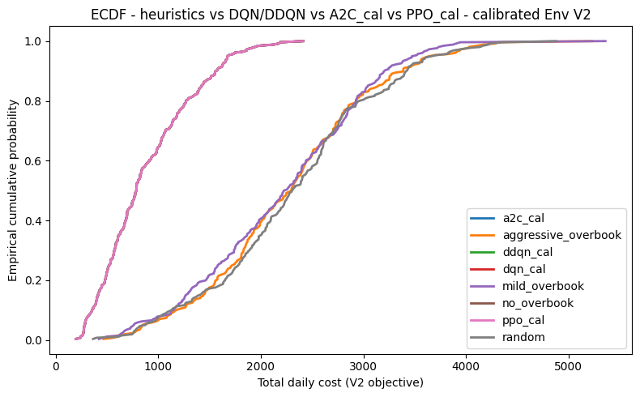

```python
ppo_cal_v2, logs_ppo_cal_v2 = train_ppo_v2(cfg_calibrated)

# Plot training rewards
plt.figure(figsize=(8, 4))
plt.plot(logs_ppo_cal_v2["rewards"])
plt.xlabel("Episode")
plt.ylabel("Return")
plt.title("PPO training rewards - calibrated Env V2")
plt.tight_layout()
path_ppo_cal_plot = os.path.join(
    ART_DIR, f"ppo_rewards_envv2_calibrated_{now_tag()}.png"
)
plt.savefig(path_ppo_cal_plot, dpi=130)
print("Saved:", path_ppo_cal_plot)


# Greedy evaluation helper (reuse the A2C-style actor-critic interface)
def evaluate_greedy_v2_ac(ac_model, env_cfg, episodes: int = 256) -> pd.DataFrame:
    env = ClinicEnvV2(env_cfg)

    def greedy(obs, env_):
        with torch.no_grad():
            x = torch.tensor(obs, dtype=torch.float32, device=device).unsqueeze(0)
            # ac_model(x) -> (logits, value)
            logits, _ = ac_model(x)
            action = int(logits.argmax(dim=-1).item())
        return action

    return pd.DataFrame([run_episode_v2(env, greedy) for _ in range(episodes)])


# Evaluate PPO on calibrated env
df_ppo_cal_v2 = evaluate_greedy_v2_ac(
    ppo_cal_v2, cfg_calibrated, episodes=256
).assign(policy="ppo_cal")

# Assemble comparison set:
#    heuristics (calibrated) + DQN/DDQN_cal + A2C_cal + PPO_cal

frames = []

# Heuristics under calibrated config (already computed in 23a)
if "df_heur_cal" in globals():
    frames.append(df_heur_cal)

# Calibrated DQN and DDQN
if "qnet_dqn_cal_v2" in globals():
    df_dqn_cal = evaluate_greedy_v2(
        qnet_dqn_cal_v2, cfg_calibrated, episodes=256
    ).assign(policy="dqn_cal")
    frames.append(df_dqn_cal)

if "qnet_ddqn_cal_v2" in globals():
    df_ddqn_cal = evaluate_greedy_v2(
        qnet_ddqn_cal_v2, cfg_calibrated, episodes=256
    ).assign(policy="ddqn_cal")
    frames.append(df_ddqn_cal)

# Calibrated A2C from 23a
if "df_a2c_cal_v2" in globals():
    frames.append(df_a2c_cal_v2)

# Add PPO_cal
frames.append(df_ppo_cal_v2)

df_cmp_ppo_cal = pd.concat(frames, ignore_index=True)

# Summary table
summary_ppo_cal = summarize_v2(df_cmp_ppo_cal, alpha=0.05)
summary_ppo_cal = summary_ppo_cal.sort_values("mean_cost_v2")
print("Heuristics vs DQN/DDQN vs A2C_cal vs PPO_cal (calibrated Env V2)")
print(summary_ppo_cal)

# ECDF plot
plt.figure(figsize=(8, 5))
focus_policies = [
    "no_overbook",
    "mild_overbook",
    "aggressive_overbook",
    "random",
    "dqn_cal",
    "ddqn_cal",
    "a2c_cal",
    "ppo_cal",
]

for name, g in df_cmp_ppo_cal.groupby("policy"):
    if name not in focus_policies:
        continue
    y, x = ecdf(g["cost_total_v2"].to_numpy())
    plt.plot(y, x, label=name, linewidth=2.0)

plt.xlabel("Total daily cost (V2 objective)")
plt.ylabel("Empirical cumulative probability")
plt.title("ECDF - heuristics vs DQN/DDQN vs A2C_cal vs PPO_cal - calibrated Env V2")
plt.legend()
plt.tight_layout()
path_ecdf_ppo_cal = os.path.join(
    ART_DIR, f"ecdf_envv2_calibrated_ppo_{now_tag()}.png"
)
plt.savefig(path_ecdf_ppo_cal, dpi=130)
print("Saved:", path_ecdf_ppo_cal)
```

PPO is retrained on the calibrated Env V2, using the same configuration as in the baseline experiments but with the updated no-show and service-time parameters from the Kaggle and MDPI datasets. The training curve shows returns improving from very negative values to a stable band around −400 to −300, indicating adaptation to the harsher calibrated cost structure. When evaluated against the heuristic policies and the calibrated DQN, Double DQN, and A2C agents, `PPO_cal` achieves essentially identical mean cost, CVaR, and throughput to the conservative `no_overbook` policy, while overbooking and random scheduling remain substantially more expensive and riskier in the tail.

# 23c Rainbow DQN with calibrated config + comparison

Here the Rainbow-style DQN from Section 17 is retrained using the calibrated parameters. The training loop is unchanged, but the agent now experiences more realistic service times and no-show variability. Once training is complete, the greedy Rainbow policy is evaluated and added to the calibrated comparison table. The section investigates whether the dueling architecture, prioritized replay, and Double DQN target allow Rainbow to adapt more effectively to the calibrated environment than plain DQN. It also checks whether these enhancements improve or worsen tail behavior under the V2 cost.

```
[Rainbow-V2] step=  4000 episodes= 125 last_return=-835.09
[Rainbow-V2] step=  8000 episodes= 250 last_return=-835.01
[Rainbow-V2] step= 12000 episodes= 375 last_return=-1314.64
[Rainbow-V2] step= 16000 episodes= 500 last_return=-569.40
[Rainbow-V2] step= 20000 episodes= 625 last_return=-769.83
[Rainbow-V2] step= 24000 episodes= 750 last_return=-490.68
[Rainbow-V2] step= 28000 episodes= 875 last_return=-416.03
[Rainbow-V2] step= 32000 episodes=1000 last_return=-541.42
[Rainbow-V2] step= 36000 episodes=1125 last_return=-288.72
[Rainbow-V2] step= 40000 episodes=1250 last_return=-298.99
Saved: report_artifacts/rainbow_rewards_envv2_calibrated_20251125_025052.png
Heuristics vs DQN/DDQN vs A2C/PPO vs Rainbow_cal (calibrated Env V2)
                policy  mean_cost_v2  mean_cost_v2_ci_lo  mean_cost_v2_ci_hi  \
0              a2c_cal    885.837097          831.233643          942.396912
2             ddqn_cal    885.837097          831.233643          942.396912
3              dqn_cal    885.837097          831.233643          942.396912
5          no_overbook    885.837097          831.233643          942.396912
6              ppo_cal    885.837097          831.233643          942.396912
7          rainbow_cal    941.734009          879.076538         1002.371399
4        mild_overbook   2212.370605         2107.746826         2314.161133
8               random   2263.408203         2159.591309         2360.850830
1  aggressive_overbook   2279.402588         2179.580322         2379.508301

       var5_v2     cvar5_v2     served  mean_revenue  mean_shortfall_penalty
0  1678.574951  1957.992188  51.203125           0.0                     0.0
2  1678.574951  1957.992188  51.203125           0.0                     0.0
3  1678.574951  1957.992188  51.203125           0.0                     0.0
5  1678.574951  1957.992188  51.203125           0.0                     0.0
6  1678.574951  1957.992188  51.203125           0.0                     0.0
7  1904.550049  2261.769287  52.281250           0.0                     0.0
4  3483.850098  3830.184814  57.347656           0.0                     0.0
8  3596.125000  3881.907471  57.687500           0.0                     0.0
1  3650.375000  4107.484375  57.511719           0.0                     0.0
Saved: report_artifacts/ecdf_envv2_calibrated_rainbow_20251125_025056.png
```

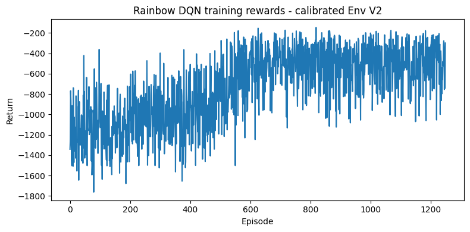

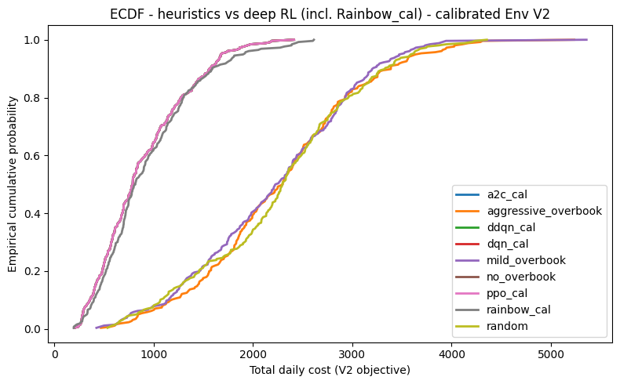

```python
# Train Rainbow on the calibrated environment
qnet_rainbow_cal_v2, logs_rainbow_cal_v2 = run_rainbow_v2(cfg_calibrated)

# Plot Rainbow training rewards
plt.figure(figsize=(8, 4))
plt.plot(logs_rainbow_cal_v2["rewards"])
plt.xlabel("Episode")
plt.ylabel("Return")
plt.title("Rainbow DQN training rewards - calibrated Env V2")
plt.tight_layout()
path_rainbow_cal_plot = os.path.join(
    ART_DIR, f"rainbow_rewards_envv2_calibrated_{now_tag()}.png"
)
plt.savefig(path_rainbow_cal_plot, dpi=130)
print("Saved:", path_rainbow_cal_plot)

# Evaluation on calibrated Env V2

# Heuristic baselines under calibrated config
df_heur_cal = eval_policies_v2(cfg_calibrated, POLICIES, episodes=256)

frames = [df_heur_cal]

# Add calibrated value-based / actor–critic methods
if "df_dqn_cal" in globals():
    frames.append(df_dqn_cal)
if "df_ddqn_cal" in globals():
    frames.append(df_ddqn_cal)
if "df_a2c_cal_v2" in globals():
    frames.append(df_a2c_cal_v2)
if "df_ppo_cal_v2" in globals():
    frames.append(df_ppo_cal_v2)

# Rainbow_cal evaluation (mean-greedy over quantile distribution)
df_rainbow_cal_v2 = evaluate_greedy_v2(
    qnet_rainbow_cal_v2, cfg_calibrated, episodes=256
).assign(policy="rainbow_cal")
frames.append(df_rainbow_cal_v2)

df_cmp_rainbow_cal = pd.concat(frames, ignore_index=True)

summary_rainbow_cal = summarize_v2(df_cmp_rainbow_cal, alpha=0.05)
summary_rainbow_cal = summary_rainbow_cal.sort_values("mean_cost_v2")
print("Heuristics vs DQN/DDQN vs A2C/PPO vs Rainbow_cal (calibrated Env V2)")
print(summary_rainbow_cal)

# ECDF plot
plt.figure(figsize=(8, 5))
focus_policies = [
    "no_overbook",
    "mild_overbook",
    "aggressive_overbook",
    "random",
    "dqn_cal",
    "ddqn_cal",
    "a2c_cal",
    "ppo_cal",
    "rainbow_cal",
]
for name, g in df_cmp_rainbow_cal.groupby("policy"):
    if name not in focus_policies:
        continue
    y, x = ecdf(g["cost_total_v2"].to_numpy())
    plt.plot(y, x, label=name, linewidth=2.0)

plt.xlabel("Total daily cost (V2 objective)")
plt.ylabel("Empirical cumulative probability")
plt.title("ECDF - heuristics vs deep RL (incl. Rainbow_cal) - calibrated Env V2")
plt.legend()
plt.tight_layout()
path_ecdf_rainbow_cal = os.path.join(
    ART_DIR, f"ecdf_envv2_calibrated_rainbow_{now_tag()}.png"
)
plt.savefig(path_ecdf_rainbow_cal, dpi=130)
print("Saved:", path_ecdf_rainbow_cal)
```

# 23d QR-DQN (distributional) with calibrated config + comparison

This section brings the distributional QR-DQN agent into the calibrated setting. The network is retrained to approximate the full return distribution under the calibrated V2 objective, and training curves track how its returns evolve. Evaluation uses the mean of the predicted quantiles for decision-making but places particular emphasis on VaR and CVaR estimates, since distributional RL is well suited to tail analysis. The calibrated QR-DQN results are then merged into the global comparison table. This section shows whether explicitly modeling uncertainty in returns adds practical value in a real-data-inspired clinic.

```
[QR-DQN-V2] step=  4000 episodes= 125 last_return=-1327.98
[QR-DQN-V2] step=  8000 episodes= 250 last_return=-1240.47
[QR-DQN-V2] step= 12000 episodes= 375 last_return=-779.70
[QR-DQN-V2] step= 16000 episodes= 500 last_return=-686.18
[QR-DQN-V2] step= 20000 episodes= 625 last_return=-610.10
[QR-DQN-V2] step= 24000 episodes= 750 last_return=-666.42
[QR-DQN-V2] step= 28000 episodes= 875 last_return=-847.75
[QR-DQN-V2] step= 32000 episodes=1000 last_return=-565.44
[QR-DQN-V2] step= 36000 episodes=1125 last_return=-593.25
[QR-DQN-V2] step= 40000 episodes=1250 last_return=-549.71
Saved: report_artifacts/qrdqn_rewards_envv2_calibrated_20251125_025708.png
Heuristics vs all deep RL (incl. QR-DQN_cal) - calibrated Env V2
                policy  mean_cost_v2  mean_cost_v2_ci_lo  mean_cost_v2_ci_hi  \
0              a2c_cal    885.837097          831.233643          942.396912
2             ddqn_cal    885.837097          831.233643          942.396912
3              dqn_cal    885.837097          831.233643          942.396912
5          no_overbook    885.837097          831.233643          942.396912
6              ppo_cal    885.837097          831.233643          942.396912
7            qrdqn_cal    899.870361          845.455933          958.918640
8          rainbow_cal    941.734009          879.076538         1002.371399
4        mild_overbook   2212.370605         2107.746826         2314.161133
1  aggressive_overbook   2279.402588         2179.580322         2379.508301
9               random   2308.210449         2214.229004         2403.383057

       var5_v2     cvar5_v2     served  mean_revenue  mean_shortfall_penalty
0  1678.574951  1957.992188  51.203125           0.0                     0.0
2  1678.574951  1957.992188  51.203125           0.0                     0.0
3  1678.574951  1957.992188  51.203125           0.0                     0.0
5  1678.574951  1957.992188  51.203125           0.0                     0.0
6  1678.574951  1957.992188  51.203125           0.0                     0.0
7  1797.224976  2076.669189  51.500000           0.0                     0.0
8  1904.550049  2261.769287  52.281250           0.0                     0.0
4  3483.850098  3830.184814  57.347656           0.0                     0.0
1  3650.375000  4107.484375  57.511719           0.0                     0.0
9  3823.225098  4110.684570  57.445312           0.0                     0.0
Saved: report_artifacts/ecdf_envv2_calibrated_qrdqn_20251125_025712.png
```

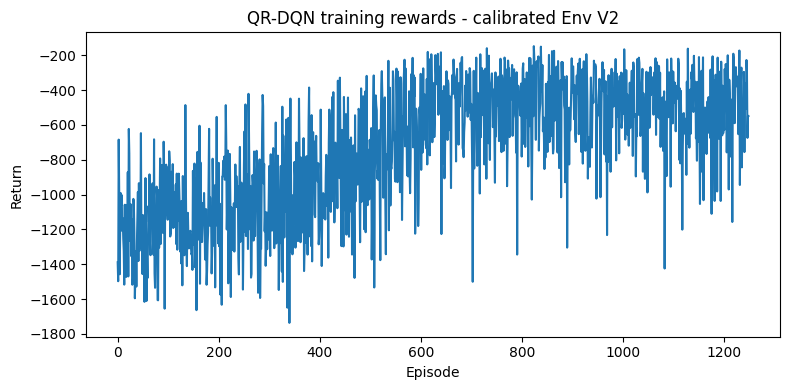

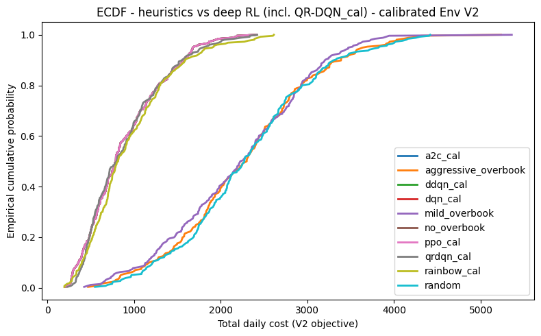

```python
# Train QR-DQN on the calibrated environment
qnet_qr_cal_v2, logs_qr_cal_v2 = run_qrdqn_v2(cfg_calibrated)

# Plot QR-DQN training rewards
plt.figure(figsize=(8, 4))
plt.plot(logs_qr_cal_v2["rewards"])
plt.xlabel("Episode")
plt.ylabel("Return")
plt.title("QR-DQN training rewards - calibrated Env V2")
plt.tight_layout()
path_qr_cal_plot = os.path.join(
    ART_DIR, f"qrdqn_rewards_envv2_calibrated_{now_tag()}.png"
)
plt.savefig(path_qr_cal_plot, dpi=130)
print("Saved:", path_qr_cal_plot)

# Evaluation on calibrated Env V2

# Evaluate QR-DQN with its quantile-aware greedy policy
df_qrdqn_cal_v2 = evaluate_qrdqn_v2(
    qnet_qr_cal_v2, cfg_calibrated, episodes=256
).assign(policy="qrdqn_cal")

# Heuristics again (calibrated)
df_heur_cal = eval_policies_v2(cfg_calibrated, POLICIES, episodes=256)

frames = [df_heur_cal]

# Add all previously trained calibrated methods
if "df_dqn_cal" in globals():
    frames.append(df_dqn_cal)
if "df_ddqn_cal" in globals():
    frames.append(df_ddqn_cal)
if "df_a2c_cal_v2" in globals():
    frames.append(df_a2c_cal_v2)
if "df_ppo_cal_v2" in globals():
    frames.append(df_ppo_cal_v2)
if "df_rainbow_cal_v2" in globals():
    frames.append(df_rainbow_cal_v2)

frames.append(df_qrdqn_cal_v2)

df_cmp_qr_cal = pd.concat(frames, ignore_index=True)

summary_qr_cal = summarize_v2(df_cmp_qr_cal, alpha=0.05)
summary_qr_cal = summary_qr_cal.sort_values("mean_cost_v2")
print("Heuristics vs all deep RL (incl. QR-DQN_cal) - calibrated Env V2")
print(summary_qr_cal)

# ECDF plot including QR-DQN_cal
plt.figure(figsize=(8, 5))
focus_policies = [
    "no_overbook",
    "mild_overbook",
    "aggressive_overbook",
    "random",
    "dqn_cal",
    "ddqn_cal",
    "a2c_cal",
    "ppo_cal",
    "rainbow_cal",
    "qrdqn_cal",
]
for name, g in df_cmp_qr_cal.groupby("policy"):
    if name not in focus_policies:
        continue
    y, x = ecdf(g["cost_total_v2"].to_numpy())
    plt.plot(y, x, label=name, linewidth=2.0)

plt.xlabel("Total daily cost (V2 objective)")
plt.ylabel("Empirical cumulative probability")
plt.title("ECDF - heuristics vs deep RL (incl. QR-DQN_cal) - calibrated Env V2")
plt.legend()
plt.tight_layout()
path_ecdf_qr_cal = os.path.join(
    ART_DIR, f"ecdf_envv2_calibrated_qrdqn_{now_tag()}.png"
)
plt.savefig(path_ecdf_qr_cal, dpi=130)
print("Saved:", path_ecdf_qr_cal)
```

# 24 Final calibrated summary for Env V2

```python
EVAL_EPISODES = 256  # keep consistent with earlier evaluations

frames_final = []

# Heuristic baselines under calibrated config
if "df_heur_cal" in globals():
    frames_final.append(df_heur_cal)
else:
    df_heur_cal = eval_policies_v2(cfg_calibrated, POLICIES, episodes=EVAL_EPISODES)
    frames_final.append(df_heur_cal)

# Calibrated value-based DQN / Double DQN
if "df_dqn_cal" in globals():
    frames_final.append(df_dqn_cal)
elif "qnet_dqn_cal_v2" in globals():
    frames_final.append(
        evaluate_greedy_v2(qnet_dqn_cal_v2, cfg_calibrated, episodes=EVAL_EPISODES)
        .assign(policy="dqn_cal")
    )

if "df_ddqn_cal" in globals():
    frames_final.append(df_ddqn_cal)
elif "qnet_ddqn_cal_v2" in globals():
    frames_final.append(
        evaluate_greedy_v2(qnet_ddqn_cal_v2, cfg_calibrated, episodes=EVAL_EPISODES)
        .assign(policy="ddqn_cal")
    )

# Calibrated actor–critic methods
if "df_a2c_cal_v2" in globals():
    frames_final.append(df_a2c_cal_v2)

if "df_ppo_cal_v2" in globals():
    frames_final.append(df_ppo_cal_v2)

# Distributional and Rainbow-style DQN (calibrated)
if "df_qrdqn_cal_v2" in globals():
    frames_final.append(df_qrdqn_cal_v2)

if "df_rainbow_cal_v2" in globals():
    frames_final.append(df_rainbow_cal_v2)

# Concatenate everything and build summary
df_all_calibrated_v2 = pd.concat(frames_final, ignore_index=True)

summary_all_calibrated_v2 = summarize_v2(df_all_calibrated_v2, alpha=0.05)
summary_all_calibrated_v2 = summary_all_calibrated_v2.sort_values("mean_cost_v2")

print("Final calibrated summary (Env V2) – heuristics vs all deep RL")
print(summary_all_calibrated_v2)

# saves the table for the report
summary_path = os.path.join(
    ART_DIR, f"summary_envv2_calibrated_final_{now_tag()}.csv"
)
summary_all_calibrated_v2.to_csv(summary_path)
print("Saved final calibrated summary table to:", summary_path)
```

```
Final calibrated summary (Env V2) – heuristics vs all deep RL
                policy  mean_cost_v2  mean_cost_v2_ci_lo  mean_cost_v2_ci_hi  \
0              a2c_cal    885.837097          831.233643          942.396912
2             ddqn_cal    885.837097          831.233643          942.396912
3              dqn_cal    885.837097          831.233643          942.396912
5          no_overbook    885.837097          831.233643          942.396912
6              ppo_cal    885.837097          831.233643          942.396912
7            qrdqn_cal    899.870361          845.455933          958.918640
8          rainbow_cal    941.734009          879.076538         1002.371399
4        mild_overbook   2212.370605         2107.746826         2314.161133
1  aggressive_overbook   2279.402588         2179.580322         2379.508301
9               random   2308.210449         2214.229004         2403.383057

       var5_v2     cvar5_v2     served  mean_revenue  mean_shortfall_penalty
0  1678.574951  1957.992188  51.203125           0.0                     0.0
2  1678.574951  1957.992188  51.203125           0.0                     0.0
3  1678.574951  1957.992188  51.203125           0.0                     0.0
5  1678.574951  1957.992188  51.203125           0.0                     0.0
6  1678.574951  1957.992188  51.203125           0.0                     0.0
7  1797.224976  2076.669189  51.500000           0.0                     0.0
8  1904.550049  2261.769287  52.281250           0.0                     0.0
4  3483.850098  3830.184814  57.347656           0.0                     0.0
1  3650.375000  4107.484375  57.511719           0.0                     0.0
9  3823.225098  4110.684570  57.445312           0.0                     0.0
Saved final calibrated summary table to: report_artifacts/summary_envv2_calibrated_final_20251125_031012.csv
```